## Práctica Grafos: Aeropuertos y rutas en EEUU

### Máster Data Science para Finanzas CUNEF

#### Daniel Corral Ruiz, Antonio Pascual Hernández

# ¿Qué es un grafo?

Un grafo en su totalidad es un par ordenado compuesto por vértices (son los puntos o nodos con los que está conformado un grafo) y aristas (son las líneas con las que se unen las aristas de un grafo y con la que se construyen también caminos); donde en la gran mayoría de los casos los vértices son de cuantificación finita. El número de vértices que componen al grafo, son las que conocemos como orden. Existe también el concepto de grado que se corresponde al número de arcos al que pertenecen de forma externa y en cuanto a las aristas también conseguimos el concepto de bucle que no es más que una arista relacionada de diversas formas con el mismo nodo. Adicionalmente los grafos son implementados cada vez más en sistemas de prevención de fraude bancario y de prevención del blanqueo de capitales. Estos permiten establecer patrones de comportamiento sospechoso y buscar a nivel de detalle la existencia de relaciones que demuestren operaciones fraudulentas. Teniendo claros estos conceptos, podemos empezar a profundizar en las definiciones de tipos de grafos. Existen diversos tipos de grafos, analizaremos en esta oportunidad los esquemas de grafos más conocidos como son los grafos dirigidos, no dirigidos y etiquetados:

- **Grafo dirigido**: Un grafo dirigido conocido también como dígrafo consta de un conjunto de vértices y aristas donde cada arista se asocia de forma unidireccional a través de una flecha con otro. Las aristas dependiendo de su salida o ingreso reciben la calificación de entrante o saliente, la condición común, es que siempre tienen un destino hacia un nodo.
- **Grafo no dirigido** : Los grafos no dirigidos son aquellos que constan un conjunto de vértices que están conectados a un conjunto de aristas de forma no direccional. Esto significa que una arista puede indistintamente recorrerse desde cualquiera de sus puntos y en cualquier dirección.
- **Grafos etiquetados** : Esta clasificación es denominada como grafos etiquetados o grafos dirigidos con pesos. Este tipo de grafos concentran aristas que pueden poseer información adicional donde podemos reflejar nombres, costos, valores u otros datos. Estos grafos también son denominados como redes de actividad y el número asociado al arco, se le denomina factor de peso. Este grafo es el que más comúnmente utilizamos para representar situaciones de la vida real.

# Introducción

El objetivo de esta práctica es estudiar las relaciones entre los aeropuertos y las rutas de los vuelos de EEUU mediante grafos, con la finalidad de entender como están distribuidas las rutas aéreas en este país.

A continuación, cargaremos los paquetes necesarios para la realización de la práctica. Para ello hacemos uso de las librerias "pandas" y "numpy" para la extracción y tratamiento de los datos. Así mismo, hemos cargado las librerias "networkx" y "matplotlib" para análizar e interpretar estructuras de redes complejas, que en nuestro caso será la representación de vuelos y aeropuertos de EEUU.

```python
import pandas as pd
import numpy as np
import networkx as nx
import matplotlib.pyplot as plt
```

- **IATA**: El código de aeropuertos de IATA es un código de tres letras que designa a cada aeropuerto en el mundo. Estos códigos son decididos por la Asociación Internacional de Transporte Aéreo (International Air Transport Association) IATA.
- **ICAO**: Los códigos OACI son designados por la Organización de Aviación Civil Internacional (OACI) y son utilizados por los profesionales más “aeronáuticos” del sector del transporte aéreo (controladores, pilotos…), por lo que en general son menos conocidos por el pasajero de a pie.

```python
# descargamos datos de aeropuertos
# en primer lugar asignamos nombre de las variables
aeropuertos_nombres = ('id,aeropuerto,ciudad,país,iata,icao,latitud,longitud,'
         'altura,timezone,dst,tz,tipo,origen').split(',')
# descargamos datos
aeropuertos = pd.read_csv("https://raw.githubusercontent.com/jpatokal/openflights/master/data/airports.dat",
                        names = aeropuertos_nombres, index_col = 4, na_values='\\N')
# descargamos datos de rutas
# en primer lugar asignamos nombre de las variables
rutas_nombres = ('aerolínea,aerolínea_id,'
         'origen,origen_id,'
         'destino,destino_id,'
         'codeshare,paradas,flota').split(',')
rutas = pd.read_csv("https://raw.githubusercontent.com/jpatokal/openflights/master/data/routes.dat",
                        names = rutas_nombres)
```

Mediante la función head, comprobamos que los datos estén correctamente descargados.

```python
rutas.head(10)
```

|  | aerolínea | aerolínea_id | origen | origen_id | destino | destino_id | codeshare | paradas | flota |
| --- | --- | --- | --- | --- | --- | --- | --- | --- | --- |
| 0 | 2B | 410 | AER | 2965 | KZN | 2990 | NaN | 0 | CR2 |
| 1 | 2B | 410 | ASF | 2966 | KZN | 2990 | NaN | 0 | CR2 |
| 2 | 2B | 410 | ASF | 2966 | MRV | 2962 | NaN | 0 | CR2 |
| 3 | 2B | 410 | CEK | 2968 | KZN | 2990 | NaN | 0 | CR2 |
| 4 | 2B | 410 | CEK | 2968 | OVB | 4078 | NaN | 0 | CR2 |
| 5 | 2B | 410 | DME | 4029 | KZN | 2990 | NaN | 0 | CR2 |
| 6 | 2B | 410 | DME | 4029 | NBC | 6969 | NaN | 0 | CR2 |
| 7 | 2B | 410 | DME | 4029 | TGK | \N | NaN | 0 | CR2 |
| 8 | 2B | 410 | DME | 4029 | UUA | 6160 | NaN | 0 | CR2 |
| 9 | 2B | 410 | EGO | 6156 | KGD | 2952 | NaN | 0 | CR2 |

Comprobamos mediante la función "head" la correcta importación de los datos.

```python
aeropuertos.head(10)
```

| iata | id | aeropuerto | ciudad | país | icao | latitud | longitud | altura | timezone | dst | tz | tipo | origen |
| --- | --- | --- | --- | --- | --- | --- | --- | --- | --- | --- | --- | --- | --- |
| GKA | 1 | Goroka Airport | Goroka | Papua New Guinea | AYGA | -6.081690 | 145.391998 | 5282 | 10.0 | U | Pacific/Port_Moresby | airport | OurAirports |
| MAG | 2 | Madang Airport | Madang | Papua New Guinea | AYMD | -5.207080 | 145.789001 | 20 | 10.0 | U | Pacific/Port_Moresby | airport | OurAirports |
| HGU | 3 | Mount Hagen Kagamuga Airport | Mount Hagen | Papua New Guinea | AYMH | -5.826790 | 144.296005 | 5388 | 10.0 | U | Pacific/Port_Moresby | airport | OurAirports |
| LAE | 4 | Nadzab Airport | Nadzab | Papua New Guinea | AYNZ | -6.569803 | 146.725977 | 239 | 10.0 | U | Pacific/Port_Moresby | airport | OurAirports |
| POM | 5 | Port Moresby Jacksons International Airport | Port Moresby | Papua New Guinea | AYPY | -9.443380 | 147.220001 | 146 | 10.0 | U | Pacific/Port_Moresby | airport | OurAirports |
| WWK | 6 | Wewak International Airport | Wewak | Papua New Guinea | AYWK | -3.583830 | 143.669006 | 19 | 10.0 | U | Pacific/Port_Moresby | airport | OurAirports |
| UAK | 7 | Narsarsuaq Airport | Narssarssuaq | Greenland | BGBW | 61.160500 | -45.425999 | 112 | -3.0 | E | America/Godthab | airport | OurAirports |
| GOH | 8 | Godthaab / Nuuk Airport | Godthaab | Greenland | BGGH | 64.190903 | -51.678101 | 283 | -3.0 | E | America/Godthab | airport | OurAirports |
| SFJ | 9 | Kangerlussuaq Airport | Sondrestrom | Greenland | BGSF | 67.012222 | -50.711603 | 165 | -3.0 | E | America/Godthab | airport | OurAirports |
| THU | 10 | Thule Air Base | Thule | Greenland | BGTL | 76.531197 | -68.703201 | 251 | -4.0 | E | America/Thule | airport | OurAirports |

Nuestro dataset de aeropuertos nos proporciona información de todos los aeropuertos a nivel mundial, como solo queremos centrarnos en los aeropuertos de EEUU, procedemos a filtrar seleccionando en la variable "país" unicamente los datos de "United States". Creamos un nuevo objeto con el filtrado del dataset original para los datos de EEUU.

```python
aeropuertos_us = aeropuertos[aeropuertos['país'] == 'United States'] # filtramos por los aeropuertos de EEUU.
aeropuertos_us.dropna(inplace=True) # eliminamos los NA.
aeropuertos_us.head(20)
```

| iata | id | aeropuerto | ciudad | país | icao | latitud | longitud | altura | timezone | dst | tz | tipo | origen |
| --- | --- | --- | --- | --- | --- | --- | --- | --- | --- | --- | --- | --- | --- |
| BTI | 3411 | Barter Island LRRS Airport | Barter Island | United States | PABA | 70.134003 | -143.582001 | 2 | -9.0 | A | America/Anchorage | airport | OurAirports |
| NaN | 3412 | Wainwright Air Station | Fort Wainwright | United States | PAWT | 70.613403 | -159.860001 | 35 | -9.0 | A | America/Anchorage | airport | OurAirports |
| LUR | 3413 | Cape Lisburne LRRS Airport | Cape Lisburne | United States | PALU | 68.875099 | -166.110001 | 16 | -9.0 | A | America/Anchorage | airport | OurAirports |
| PIZ | 3414 | Point Lay LRRS Airport | Point Lay | United States | PPIZ | 69.732903 | -163.005005 | 22 | -9.0 | A | America/Anchorage | airport | OurAirports |
| ITO | 3415 | Hilo International Airport | Hilo | United States | PHTO | 19.721399 | -155.048004 | 38 | -10.0 | N | Pacific/Honolulu | airport | OurAirports |
| ORL | 3416 | Orlando Executive Airport | Orlando | United States | KORL | 28.545500 | -81.332901 | 113 | -5.0 | A | America/New_York | airport | OurAirports |
| BTT | 3417 | Bettles Airport | Bettles | United States | PABT | 66.913902 | -151.529007 | 647 | -9.0 | A | America/Anchorage | airport | OurAirports |
| NaN | 3418 | Clear Airport | Clear Mews | United States | PACL | 64.301201 | -149.119995 | 552 | -9.0 | A | America/Anchorage | airport | OurAirports |
| UTO | 3419 | Indian Mountain LRRS Airport | Indian Mountains | United States | PAIM | 65.992798 | -153.703995 | 1273 | -9.0 | A | America/Anchorage | airport | OurAirports |
| FYU | 3420 | Fort Yukon Airport | Fort Yukon | United States | PFYU | 66.571503 | -145.250000 | 433 | -9.0 | A | America/Anchorage | airport | OurAirports |
| SVW | 3421 | Sparrevohn LRRS Airport | Sparrevohn | United States | PASV | 61.097401 | -155.574005 | 1585 | -9.0 | A | America/Anchorage | airport | OurAirports |
| FRN | 3422 | Bryant Army Heliport | Fort Richardson | United States | PAFR | 61.266399 | -149.653000 | 378 | -9.0 | A | America/Anchorage | airport | OurAirports |
| TLJ | 3423 | Tatalina LRRS Airport | Tatalina | United States | PATL | 62.894402 | -155.977005 | 964 | -9.0 | A | America/Anchorage | airport | OurAirports |
| CZF | 3424 | Cape Romanzof LRRS Airport | Cape Romanzof | United States | PACZ | 61.780300 | -166.039001 | 464 | -9.0 | A | America/Anchorage | airport | OurAirports |
| BED | 3425 | Laurence G Hanscom Field | Bedford | United States | KBED | 42.470001 | -71.289001 | 133 | -5.0 | A | America/New_York | airport | OurAirports |
| SNP | 3426 | St Paul Island Airport | St. Paul Island | United States | PASN | 57.167301 | -170.220001 | 63 | -9.0 | A | America/Anchorage | airport | OurAirports |
| EHM | 3427 | Cape Newenham LRRS Airport | Cape Newenham | United States | PAEH | 58.646400 | -162.063004 | 541 | -9.0 | A | America/Anchorage | airport | OurAirports |
| STG | 3428 | St George Airport | Point Barrow | United States | PAPB | 56.578300 | -169.662003 | 125 | -9.0 | A | America/Anchorage | airport | OurAirports |
| ILI | 3429 | Iliamna Airport | Iliamna | United States | PAIL | 59.754398 | -154.910996 | 192 | -9.0 | A | America/Anchorage | airport | OurAirports |
| PTU | 3430 | Platinum Airport | Port Moller | United States | PAPM | 59.011398 | -161.820007 | 15 | -9.0 | A | America/Anchorage | airport | OurAirports |

Podemos estudiar las diferentes zonas horarias que presentan los aeropuertos de EEUU. Más adelante estudiaremos visualmente como se reparten los aeropuertos en las distintas zonas horarias.

```python
aeropuertos_us['tz'].unique()
```

```
array(['America/Anchorage', 'Pacific/Honolulu', 'America/New_York',
       'America/Los_Angeles', 'America/Chicago', 'America/Denver',
       'America/Phoenix', 'America/Adak', 'America/La_Paz',
       'Europe/Budapest', 'America/Santiago', 'America/Costa_Rica'],
      dtype=object)
```

Procedemos a juntar ambos datasets. Para ello selecciona tanto el origen como el destino de nuetro dataset 'rutas' y lo une mediante el índice del dataset 'aeropuertos', ya que son los códigos de los aeropuertos de EEUU.

```python
rutas_us = rutas[rutas['origen'].isin(aeropuertos_us.index) & rutas['destino'].isin(aeropuertos_us.index)]
rutas_us.head(20)
```

|  | aerolínea | aerolínea_id | origen | origen_id | destino | destino_id | codeshare | paradas | flota |
| --- | --- | --- | --- | --- | --- | --- | --- | --- | --- |
| 172 | 2O | 146 | ADQ | 3531 | KLN | 7162 | NaN | 0 | BNI |
| 177 | 2O | 146 | KLN | 7162 | KYK | 7161 | NaN | 0 | BNI |
| 260 | 3E | 10739 | BRL | 5726 | ORD | 3830 | NaN | 0 | CNC |
| 261 | 3E | 10739 | BRL | 5726 | STL | 3678 | NaN | 0 | CNC |
| 262 | 3E | 10739 | DEC | 4042 | ORD | 3830 | NaN | 0 | CNC |
| 263 | 3E | 10739 | DEC | 4042 | STL | 3678 | NaN | 0 | CNC |
| 264 | 3E | 10739 | JBR | 3591 | STL | 3678 | NaN | 0 | CNC |
| 265 | 3E | 10739 | ORD | 3830 | BRL | 5726 | NaN | 0 | CNC |
| 266 | 3E | 10739 | ORD | 3830 | DEC | 4042 | NaN | 0 | CNC |
| 267 | 3E | 10739 | STL | 3678 | BRL | 5726 | NaN | 0 | CNC |
| 268 | 3E | 10739 | STL | 3678 | DEC | 4042 | NaN | 0 | CNC |
| 269 | 3E | 10739 | STL | 3678 | JBR | 3591 | NaN | 0 | CNC |
| 280 | 3F | 16262 | KTN | 3808 | MTM | 7146 | NaN | 0 | DHP |
| 281 | 3F | 16262 | MTM | 7146 | KTN | 3808 | NaN | 0 | DHP |
| 443 | 3M | 20710 | ATL | 3682 | LWB | 6958 | NaN | 0 | SF3 |
| 444 | 3M | 20710 | ATL | 3682 | MCN | 3754 | NaN | 0 | SF3 |
| 445 | 3M | 20710 | ATL | 3682 | MEI | 4335 | NaN | 0 | SF3 |
| 446 | 3M | 20710 | ATL | 3682 | MSL | 5756 | NaN | 0 | SF3 |
| 447 | 3M | 20710 | ATL | 3682 | PIB | 5759 | NaN | 0 | SF3 |
| 448 | 3M | 20710 | ATL | 3682 | TUP | 5773 | NaN | 0 | SF3 |

A continuación crearemos los nodos, mediante las variables origen y destino de las rutas, los cuales nos indican el trayecto de los vuelos.

```python
nodos = rutas_us[['origen', 'destino']].values
nodos
```

```
array([['ADQ', 'KLN'],
       ['KLN', 'KYK'],
       ['BRL', 'ORD'],
       ...,
       ['SOW', 'PHX'],
       ['VIS', 'LAX'],
       ['WRL', 'CYS']], dtype=object)
```

Vamos a comprobar que aeropuertos presentan una mayor cantidad de rutas, tanto de origen como destino. Observamos como en ambos casos, los aeropuertos con un mayor tránsito de vuelos coinciden. En nuestro caso, son los aeropuertos de: Atlanta International Airport, Chicago O'Hare International Airport, Dallas/Fort Worth International Airport, Denver International Airport, Los Angeles International Airport.

```python
rutas_us['origen'].value_counts()
```

```
ATL    755
ORD    380
DFW    330
DEN    320
LAX    297
      ...
YKM      1
LMA      1
EGE      1
PIH      1
PSM      1
Name: origen, Length: 542, dtype: int64
```

```python
rutas_us['destino'].value_counts()
```

```
ATL    741
ORD    372
DEN    333
DFW    327
LAX    309
      ...
TWF      1
EAU      1
KFP      1
WSN      1
PSM      1
Name: destino, Length: 541, dtype: int64
```

Mediante la función "from_edgelist" hemos creado una lista de nodos para poder representarlos gráficamente.

```python
lista_nodos = nx.from_edgelist(nodos)
```

Comprobaremos el numero de aeropuertos y de vuelos que se representarán a continuación.

```python
len(lista_nodos.nodes()), len(lista_nodos.edges())
```

```
(549, 2787)
```

En total se obtienen 549 aeropuertos (son los nodos) y un total de 2787 conexiones entre ellos (las aristas). A continuación procedemos a representar gráficamente gracias a la librería 'networkx', donde podremos visualizar las conexiones.

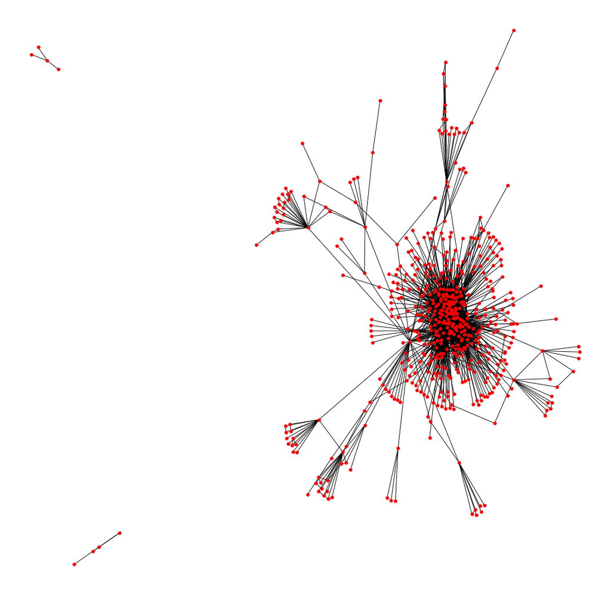

```python
fig, ax = plt.subplots(1, 1, figsize=(20, 20))
nx.draw_networkx(lista_nodos,
                 ax=ax,
                 node_size=30,
                 font_size=0,
                 alpha=1,
                 width=1,
                 node_color="r")
ax.set_axis_off()
```

A continuación vamos a estudiar como se reparten los aeropuertos por zonas horarias. Podemos observar a modo de resumen la frecuencia de los distintos valores por zona horaria mediante la funcion "value_counts()".

```python
aeropuertos_us['tz'].value_counts()
```

```
America/New_York       446
America/Chicago        342
America/Anchorage      176
America/Los_Angeles    163
America/Denver         117
America/Phoenix         36
Pacific/Honolulu        19
America/Adak             3
America/La_Paz           1
America/Santiago         1
Europe/Budapest          1
America/Costa_Rica       1
Name: tz, dtype: int64
```

Podemos observar un total de 12 zonas horarias representadas en el gráfico. Los grafos con mayor dimensión serán aquellos que presentan una mayor frecuencia la zona horaria: New_York, Chicago, Anchorage, Los_Angeles y Denver, tal y como se observan en la tabla anterior. En el resto de zonas horarias hay un menor número de aeropuertos por lo que su representación gráfica observaremos como la dimensión de los grafos es de menor tamaño. Cada agrupación de aeropuertos representará una zona horaria diferente.

```python
cluster = nx.from_pandas_edgelist(aeropuertos_us,source='id',target='tz')
```

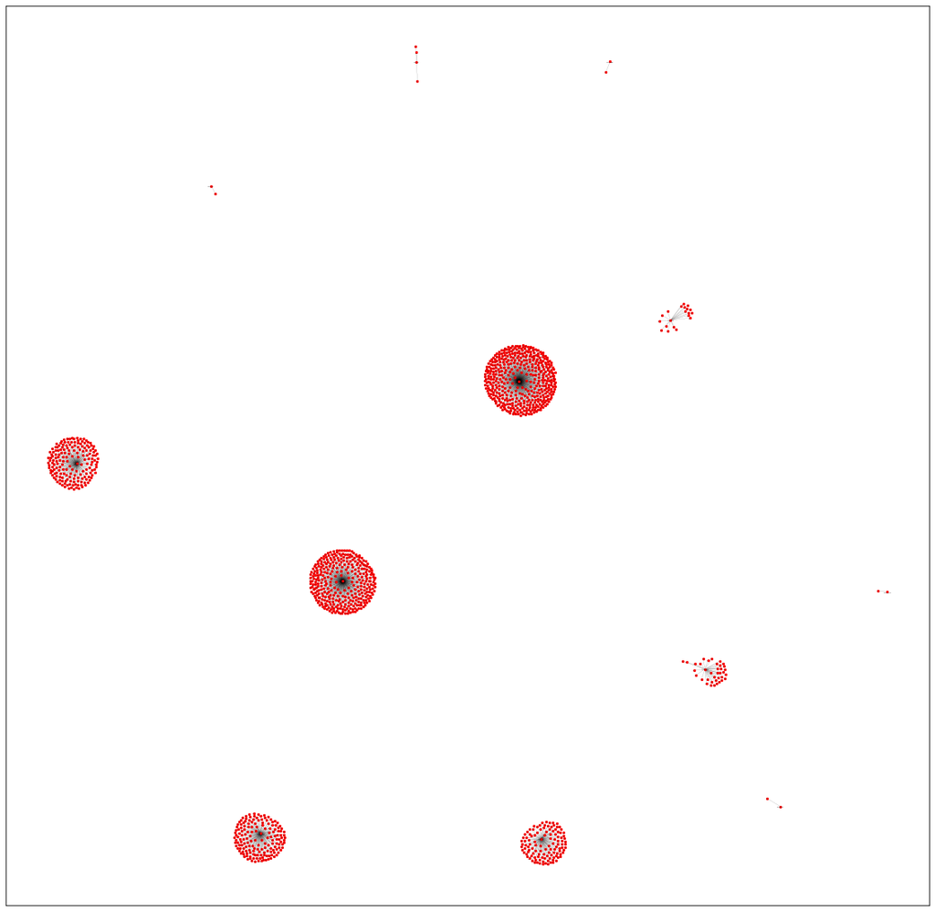

```python
plt.figure(figsize=(20, 20))
pos=nx.spring_layout(cluster)
nx.draw_networkx(cluster,
                 pos,
                 node_size=5,
                 node_color='red',
                 width=0.1,
                 font_size=1)
plt.show()
```

# Conclusiones:

Una vez hemos realizado el estudio mediante grafos, podemos resumir las siguientes conclusiones:

- En el primero de los grafos, el cual representa las rutas de los aeropuertos de EEUU, podríamos observar una mayor concentración en el centro del grafo, lo que podría corresponder al centro de EEUU, ya que como hemos comprobado anteriormente, 3 de los 5 aeropuertos con mayor tránsito se encuentran en el centro del país. A medida que nos alejamos del centro del grafo, observamos como la cantindad de rutas es cada vez menor. Además encontramos dos grafos separados del principal, que podríamos entender que hacen referencia a zonas más separadas, como Hawaii, Alaska o Costa Rica.
- En el segundo grafo, tras haber realizado un estudio por las distintas zonas horarias, hemos comprobado la cantidad de aeropuertos en cada zona horaria, teniendo un mayor número de aeropuertos aquellos grafos con mayor tamaño. Obtenemos un total de 12 grupos, que coinciden con el número de zonas horarias distintas.

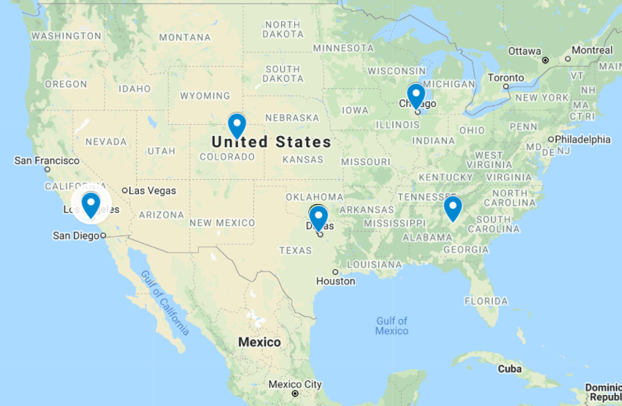

```python
from PIL import Image
Image.open('../data/Airport.png','r')
```